# Probability Density, Likelihood, and the Normal model

Petr Keil

March 2017

The purpose of this lesson is to explain the concept of **probability density** and **likelihood**, using a simple example of **Normal** probability density function.

For those with R studio, here are some optional code and libraries for interactive graphics:

```r
library(manipulate)

source("https://raw.githubusercontent.com/petrkeil/ML_and_Bayes_2017_iDiv/master/Univariate%20Normal%20Model/plotting_functions.r")
```

# 1 The data

We will use data on **housefly wing length [mm]**, which you can find [here](http://www.seattlecentral.edu/qelp/sets/057/057.html).

The original data are from Sokal & Hunter (1955) A morphometric analysis of DDT-resistant and non-resistant housefly strains *Ann. Entomol. Soc. Amer.* **48**: 499-507.

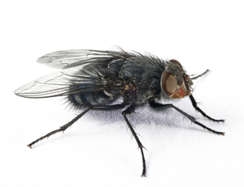

housefly

To fetch the data directly from the web, run:

```r
wings <- read.table("http://goo.gl/4lPBG6", header=FALSE)[,1]*0.1
```

Let’s examine the data:

```r
wings
```

```
##   [1] 3.6 3.7 3.8 3.8 3.9 3.9 4.0 4.0 4.0 4.0 4.1 4.1 4.1 4.1 4.1 4.1 4.2 4.2
##  [19] 4.2 4.2 4.2 4.2 4.2 4.3 4.3 4.3 4.3 4.3 4.3 4.3 4.3 4.4 4.4 4.4 4.4 4.4
##  [37] 4.4 4.4 4.4 4.4 4.5 4.5 4.5 4.5 4.5 4.5 4.5 4.5 4.5 4.5 4.6 4.6 4.6 4.6
##  [55] 4.6 4.6 4.6 4.6 4.6 4.6 4.7 4.7 4.7 4.7 4.7 4.7 4.7 4.7 4.7 4.8 4.8 4.8
##  [73] 4.8 4.8 4.8 4.8 4.8 4.9 4.9 4.9 4.9 4.9 4.9 4.9 5.0 5.0 5.0 5.0 5.0 5.0
##  [91] 5.1 5.1 5.1 5.1 5.2 5.2 5.3 5.3 5.4 5.5
```

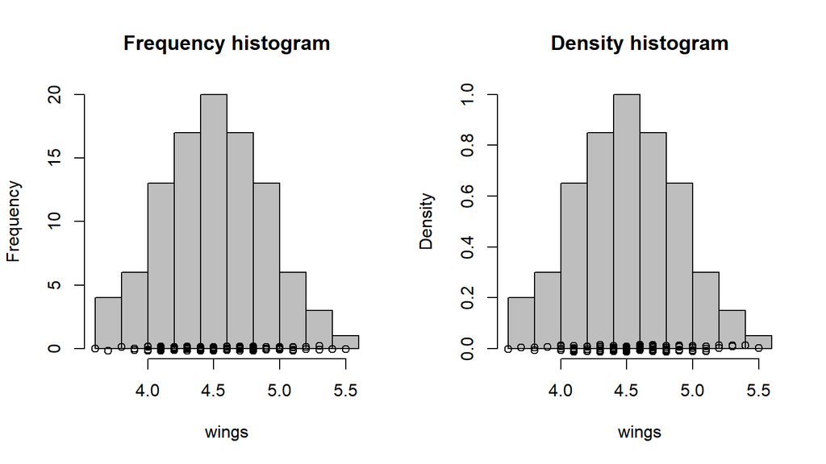

```r
par(mfrow=c(1,2))
hist(wings, freq=TRUE, col="grey", main="Frequency histogram")
points(wings, jitter(rep(0, times=100), factor=10))
hist(wings, freq=FALSE, col="grey", main="Density histogram")
points(wings, jitter(rep(0, times=100), factor=0.7))
```

# 2 The Normal model

This is our formal model definition:

$$p(x) = \frac{1}{\sqrt{2\pi}\sigma}e^{-(x-\mu)^2/(2\sigma^2)}$$

where $p()$ is **probability density function** (also known as PDF). The function has two parameters: $\mu$ (mean) and $\sigma$ (standard deviation).

For $\mu = 0$ and $\sigma = 1$ the model looks like this:

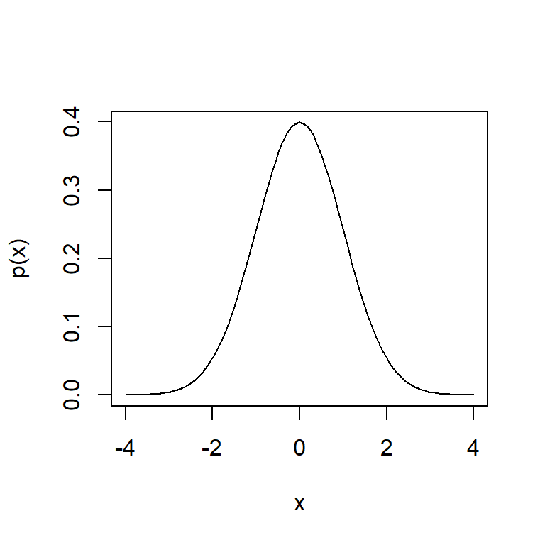

```r
  curve(dnorm, from=-4, to=4, ylab="p(x)")
```

**Remember:**

- Probability density is different from probability.
- Probability density is denoted by $p$, while probability is $P$.
- Probability density can be higher than 1.
- Probability density function must integrate to 1.
- *Probability distribution* is an ambiguous term.

# 3 Fitting the model to the wing data

**KEY PROBLEM:** How do we decide which parametrization is the best for our data?

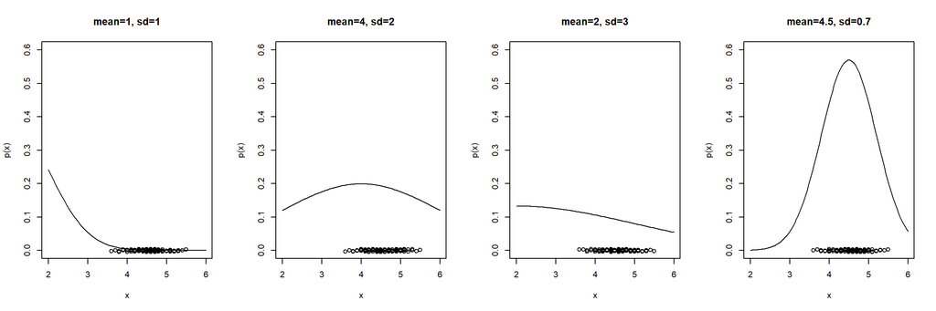

We can make this interactive using `manipulate`:

```r
manipulate(curve.data(mean, sd),
           mean=slider(2, 7, step=0.01),
           sd=slider(0.1,3, step=0.01, initial=1) )
```

## 3.1 Likelihood - single data point

The *likelihood function* is the **density** evaluated at the data $x_1$, … ,$x_n$, viewed as a function of model parameters ($\mu$ and $\sigma$ in case of the Normal model). We write it as $L(\mu, \sigma | x) = p(x | \mu, \sigma)$.

**Calculation of likelihood in R is easy!** The R functions `dnorm()`, `dpois()`, `dunif()`, `dbinom()`, `dgamma()`, `dbeta()` etc. are exactly for that!

**Example:** What is the likelihood of the first data value in the `wings` dataset, given the $Normal(\mu=4, \sigma=1)$ model?

```r
my.mean = 4
my.sd = 1
```

Here is the data point that we will examine. Note that I use the letter i to denote index:

```r
wings.i <- wings[1]
wings.i
```

```
## [1] 3.6
```

Here is how you calculate the likelihood for the data point `wings.i` using the function `dnorm`:

```r
L <- dnorm(x=wings.i, mean=my.mean, sd=my.sd)
L
```

```
## [1] 0.3682701
```

Let’s plot it:

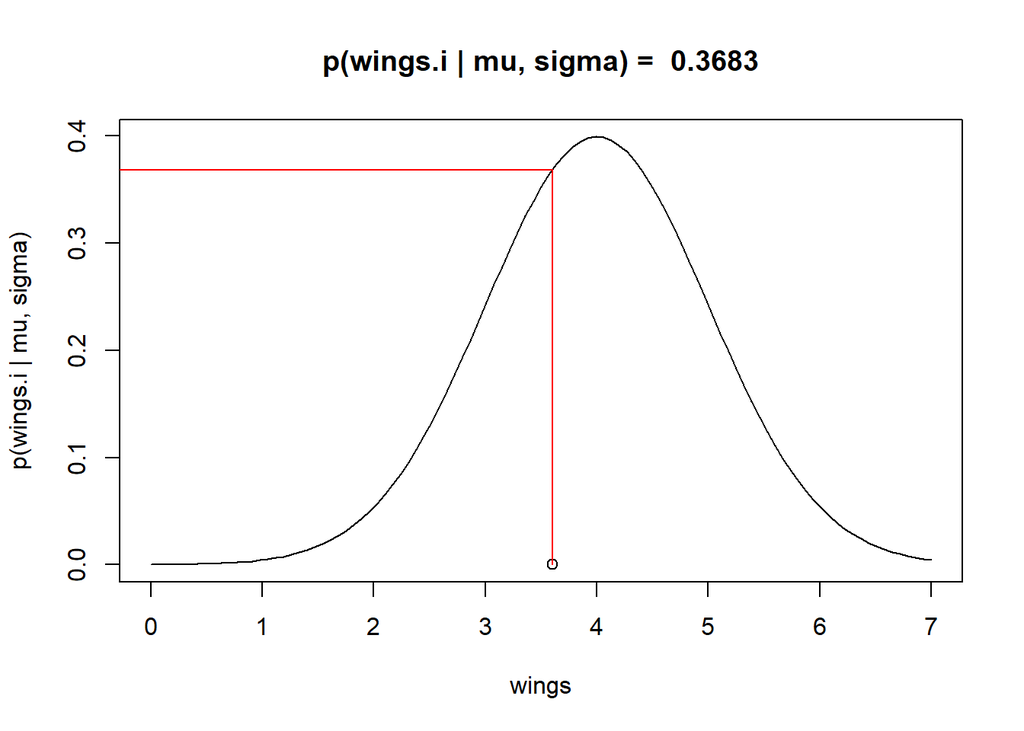

You can try some interactive graphics:

```r
manipulate(curve.data.l.point(mean, sd, point),
           point = slider(1, length(wings)),
           mean=slider(2, 7, step=0.01),
           sd=slider(0.1,3, step=0.01, initial=1) )
```

# 4 Likelihood - whole dataset

Basic probability theory tells us that:

$$P(A \cap B) = P(A) \times P(B|A) = P(B) \times P(A|B)$$

Where $P(A \cap B)$ is **joint probability**, associated with *AND*, meaning *“at the same time”*.

The problem is that joint probability for more than two events, e.g. $P( A \cap B \cap C \cap D )$, can be almost impossible to calculate, **with the exception of A and B being independent!** Then:
$$P(A \cap B) = P(A) \times P(B)$$
and hence
$$P( A \cap B \cap C \cap D ) = P(A) \times P(B) \times P(C) \times P(D)$$

It follows that it is useful to subject *probability density $p()$* to the same rules as *probability $P()$*. Hence, **we can calculate the likelihood of the whole dataset as a product of likelihoods of all individual data points!**

```r
  wings
```

```
##   [1] 3.6 3.7 3.8 3.8 3.9 3.9 4.0 4.0 4.0 4.0 4.1 4.1 4.1 4.1 4.1 4.1 4.2 4.2
##  [19] 4.2 4.2 4.2 4.2 4.2 4.3 4.3 4.3 4.3 4.3 4.3 4.3 4.3 4.4 4.4 4.4 4.4 4.4
##  [37] 4.4 4.4 4.4 4.4 4.5 4.5 4.5 4.5 4.5 4.5 4.5 4.5 4.5 4.5 4.6 4.6 4.6 4.6
##  [55] 4.6 4.6 4.6 4.6 4.6 4.6 4.7 4.7 4.7 4.7 4.7 4.7 4.7 4.7 4.7 4.8 4.8 4.8
##  [73] 4.8 4.8 4.8 4.8 4.8 4.9 4.9 4.9 4.9 4.9 4.9 4.9 5.0 5.0 5.0 5.0 5.0 5.0
##  [91] 5.1 5.1 5.1 5.1 5.2 5.2 5.3 5.3 5.4 5.5
```

```r
  L <- dnorm(x=wings, mean=my.mean, sd=my.sd)
  L
```

```
##   [1] 0.3682701 0.3813878 0.3910427 0.3910427 0.3969525 0.3969525 0.3989423
##   [8] 0.3989423 0.3989423 0.3989423 0.3969525 0.3969525 0.3969525 0.3969525
##  [15] 0.3969525 0.3969525 0.3910427 0.3910427 0.3910427 0.3910427 0.3910427
##  [22] 0.3910427 0.3910427 0.3813878 0.3813878 0.3813878 0.3813878 0.3813878
##  [29] 0.3813878 0.3813878 0.3813878 0.3682701 0.3682701 0.3682701 0.3682701
##  [36] 0.3682701 0.3682701 0.3682701 0.3682701 0.3682701 0.3520653 0.3520653
##  [43] 0.3520653 0.3520653 0.3520653 0.3520653 0.3520653 0.3520653 0.3520653
##  [50] 0.3520653 0.3332246 0.3332246 0.3332246 0.3332246 0.3332246 0.3332246
##  [57] 0.3332246 0.3332246 0.3332246 0.3332246 0.3122539 0.3122539 0.3122539
##  [64] 0.3122539 0.3122539 0.3122539 0.3122539 0.3122539 0.3122539 0.2896916
##  [71] 0.2896916 0.2896916 0.2896916 0.2896916 0.2896916 0.2896916 0.2896916
##  [78] 0.2660852 0.2660852 0.2660852 0.2660852 0.2660852 0.2660852 0.2660852
##  [85] 0.2419707 0.2419707 0.2419707 0.2419707 0.2419707 0.2419707 0.2178522
##  [92] 0.2178522 0.2178522 0.2178522 0.1941861 0.1941861 0.1713686 0.1713686
##  [99] 0.1497275 0.1295176
```

```r
  prod(L)
```

```
## [1] 1.657651e-50
```

This is a ridiculously small number! Which is why we have the **Negative Log Likelihood**:

```r
  - sum(log(L))
```

```
## [1] 114.6239
```

We can encapsulate it into a single function:

```r
  neg.LL.function <- function(x, mean, sd)
  {
    LL <- dnorm(x=x, mean=mean, sd=sd, log=TRUE) # note the log!!!
    neg.LL <- - sum(LL)
    return(neg.LL)
  }
```

It’s a function of model parameters, so try to play around with different paramter values:

```r
  neg.LL.function(wings, mean=0, sd=1)
```

```
## [1] 1134.624
```

Negative log-likelihood can be then minimized (likelihood is maximized) in order to find the most likely model parameters - these are the **Maximum Likelihood Estimators (MLE)** of model parameters.

# 5 Exercise

**Find and plot the MLE of the Normal model and the ‘wings’ data.**

Use the following functions and scripts:

```r
 neg.LL.function()
 hist()
 curve()
```

You can try some interactive graphics:

```r
manipulate(curve.data.LL(mean, sd),
           mean=slider(2, 7, step=0.01),
           sd=slider(0.1,3, step=0.01, initial=1) )
```

# 6 Using `optim()` to find MLE

`optim` needs the `neg.LL.function` to take only one object, which can be a vector (or a list). So I will just put all of the data into `dat` object, and the parameters into `par` object.

```r
neg.LL.function.for.optim <- function(par, dat)
{
  LL <- dnorm(x=dat, mean=par[1], sd=par[2], log=TRUE) # note the log!!!
  neg.LL <- - sum(LL)
  return(neg.LL)
}
```

And run the actual optimization:

```r
optim(par=c(mean=0,var=1),
      fn=neg.LL.function.for.optim,
      dat=wings)
```

```
## $par
##      mean       var
## 4.5500648 0.3899714
##
## $value
## [1] 47.733
##
## $counts
## function gradient
##      103       NA
##
## $convergence
## [1] 0
##
## $message
## NULL
```

# 7 Other functions derived from PDF

There are other functions derived from probability density function (PDF) `dnorm`:

- Cumulative distribution function (CDF) `pnorm`
- Quantile function `qnorm`
- Random number generator`rnorm`

Type `?pnorm`, `?qnorm` or `?rnorm` and check it out.

I have [a tutorial post](http://www.petrkeil.com/?p=2084) on that.